# Additive Functional Cox Model

Erjia Cui

2020-10-09

We introduce the Additive Functional Cox Model (AFCM) and show its application to the National Health and Nutritional Examination Survey (NHANES) data. Based on the selection creteria discussed at Section 1 of the paper, 2816 participants from the 2003-2004 and 2005-2006 waves of NHANES study are included. In this vignette we show (1) how to fit our model on untransformed or transformed functional covariates using the `gam()` function in the `mgcv` package, (2) how to calculate cross-validated c-index for each model and compare their predictive performance.

For simulation, we introduce a novel framework generating survival data with functional predictors which resemble the observed data. We also show how to calculate integrated squared error (ISE) to evaluate the estimation performance.

## Prerequisites

The following packages will be used in this vignette to provide illustration of the Additive Functional Cox Model.

```r
library(rnhanesdata)
library(mgcv)
library(refund)
library(caret)
library(risksetROC)
library(reshape2)
library(gridExtra)
library(fields)
library(tidyverse)
library(qgam)
library(pracma)
library(scam)
```

## Load and merge data

We first clean and organize the NHANES data into a data frame named `data_analysis`. Please first create three folders with name “code”, “figures” and “data” under current directory, then put the supplied “process_data.R” script into “code” folder before running the following code. Running the code at the first time will source “process_data.R” and save the cleaned data frame as `data_analysis.rda` in the “data” folder. For the second time and later, the following code will skip processing steps and directly load `data_analysis.rda` from “data” folder.

```r
code_path <- file.path(".","code") ## path to supplemental code
figure_path  <- file.path(".","figures") ## path to save figures
data_path <- file.path(".","data") ## path to save data
make_figures <- FALSE ## FALSE by default
save_data <- TRUE ## TRUE will save the processed data to the data_path directory

## process raw NHANES data using "process_data.R" if this has not been done yet
## or load "data_analysis.rda" if "process_data.R" has been implemented
process_data <- !file.exists(file.path(data_path, "data_analysis.rda"))
if(process_data){
    source(file.path(code_path, "process_data.R"))
} else{
    load(file.path(data_path,"data_analysis.rda"))
}
```

## Pre-processing

Suppose we observe independently censored survival outcome, and at baseline we observe $p$ scalar covariates $\mathbf{Z}_i$ and a functional covariate $\mathbf{X}_i = \{X_i(s): s \in \mathcal{S}\}$. Denote $X_i^\mathcal{P}(s) = \{X_i(u): u \leq s\}$. We posit Additive Functional Cox Model:
$$\log \lambda_i(t|\mathbf{Z}_i, \mathbf{X}_i) = \log \lambda_0(t) + \mathbf{Z}_i^T \mathbf{\beta} + \int_\mathcal{S} F\{s, h_{is}[X_i^\mathcal{P}(s)]\}ds\;,$$
where $F(\cdot, \cdot)$ is an unspecified bivariate twice differentiable function, and $h_{is}(\cdot)$ is a transformation function on the partial history of functional covariate $X_i^\mathcal{P}(s)$. In this vignette, we simplify the discussion of transformation on functional covariate $X_i(s)$.

To model the time to event outcome, we censor all mortality data at 10 years.

```r
## censor mortality data in 10 years
data_analysis$event[which(data_analysis$time_mort > 10)] <- 0
data_analysis$time_mort[which(data_analysis$time_mort > 10)] <- 10
```

In practice, we only observe functional covariates on a discrete grid of functional domain. To approximate the integral of the functional term in the model using numerical summation, we next introduce and calculate relevant variables `tmat` and `lmat`.

```r
## add intergral related variables
### function "cal_tind()" returns number of observations per subject (nt) and location of each time point in [0,1] (tind)
#### tlen: time interval, 1-minute by default as discussed in the paper
cal_tind <- function(tlen = 1){
    nt <- floor(1440/tlen) ## number of observations per subject
    tind <- seq(0, 1, len=nt) ## location of each time point in [0, 1]
    return(list(nt = nt, tind = tind))
}
### lmat: numeric integration of the functional term
data_analysis$lmat <- I(matrix(1/cal_tind(1)$nt, ncol=cal_tind(1)$nt, nrow=nrow(data_analysis)))
### tmat: time indices, [0, 1] in our case, but effectively arbitrary
data_analysis$tmat <- I(matrix(cal_tind(1)$tind, ncol=cal_tind(1)$nt, nrow=nrow(data_analysis), byrow=TRUE))
### the time interval is by hour in age-specific quantile transformation
data_analysis$lmat_qa <- I(matrix(1/cal_tind(60)$nt, ncol=cal_tind(60)$nt, nrow=nrow(data_analysis)))
data_analysis$tmat_qa <- I(matrix(cal_tind(60)$tind, ncol=cal_tind(60)$nt, nrow=nrow(data_analysis), byrow=TRUE))
```

### Transformation of functional covariates

We discussed various types of transformations $h_{is}(X_i(s))$ in the paper. Here we focus on three of them, including identity, quantile-transformation, and age-specific quantile-transformation. The functional covariate $X_i(s)$ is the smoothed log-transformed activity counts (smoothed LAC), as discussed in the paper. Note that the processed data frame `data_analysis` contains the unsmoothed LAC in the `act_log_mat` column.

We first derive the smoothed LAC using `fpca.face()` function in the `refund` package and save it as `act_log_mat_sm` in the `data_analysis`. In this case, $h_{is}(X_i(s)) = X_i(s)$. We then perform the quantile transformation on smoothed AC. In this case, $h_{is}(X_i(s)) = \text{P}\{X(s) \leq X_i(s)|s\}$, where $\{X(s): s \in \mathcal{S}\}$ is the stochastic process on the functional domain and $X_i(s)$ is the observed functional realization for the $i{\text{th}}$ study participant. Note that the range of $h_{is}(X_i(s))$ is changed to $[0,1]$. The quantile-transformed smoothed AC is denoted as `act_log_mat_sm_q`.

```r
## derive untransformed and transformed functional covariates
## 1. smoothed LAC
data_analysis$act_log_mat_sm   <- I(fpca.face(unclass(data_analysis$act_log_mat))$Yhat)
## 2. quantile-transformed smoothed LAC
data_analysis$act_log_mat_sm_q <- I(apply(data_analysis$act_log_mat_sm, 2, function(y) ecdf(y)(y)))
```

The last implemented transformation is age-specific quantile-transformation, where $h_{is}(X_i(s)) = \text{P}(X(s) \leq X_i(s)|s, \mathbf{U}_i)$. Here $\mathbf{U}_i$ refers to the covariate `age` in `data_analysis`. Since the `mqgam()` function from `qgam` package is time-consuming under such sample size, we provide the code without running it in this vignette for time purpose. However, it is implementable and takes several hours on a regular laptop.

```r
#! The code is implementable, taking several hours on a regular laptop
#! Implemented in the manuscript, by default not implemented in this vignette for efficiency
## 3. age-specific quantile-transformed smoothed LAC
### bin activity profile by hour (mqgam function is very time consuming for large nt)
data_analysis$act_log_mat_sm_hour <- I(data_analysis$act_log_mat_sm[,c(0:23)*60/5+1])
### construct data frame to perform age-specific quantile transformation
data_qreg <- data.frame("y" = as.vector(t(data_analysis$act_log_mat_sm_hour)),
                        "t" = rep(cal_tind(60)$tind, nrow(data_analysis)),
                        "age" = rep(data_analysis$Age, each=cal_tind(60)$nt))
### create quantile vector (precision = 0.01 in our example)
quantile <- seq(0.01, 0.99, by = 0.01)

### fit the additive quantile regression model for each quantile -- time consuming
#! When building the vignette, we do not actually fit this model to save time.
#! If you would like to reproduce all the plots in Figure 4, it is necessary to run this step
#! Otherwise please skip all steps related to age-specific quantile transformation below
fit <- mqgam(list(y ~ te(t,age, bs=c("cc","cr"),k=c(5,5)), ~ s(t, bs="cc")) , data=data_qreg, qu = quantile)

### derive and add pre-smoothed and age-specific quantile-transformed AC
data_analysis$act_log_mat_sm_qa <- I(matrix(0, nrow = nrow(data_analysis), ncol = cal_tind(60)$nt))
for(i in 1:nrow(data_analysis)){
    mat <- matrix(0, nrow = length(quantile), ncol = cal_tind(60)$nt)
    ## for each individual, extract the quantile matrix of its age
    for(j in 1:length(quantile)){
        mat[j,] <- fit$fit[[j]]$fitted.values[which(data_qreg$age == data_analysis$Age[i])][1:24]
    }
    ## find the approximate quantile at each time
    for(t in 1:ncol(mat)){
        data_analysis$act_log_mat_sm_qa[i, t] <- quantile[max(which(mat[,t] < data_analysis$act_log_mat_sm_hour[i, t]))]
    }
}
rm("data_qreg")
```

In addition, we derive the daily average smoothed LAC of each participant, denoted as `act_log_mat_ave`. It is a scalar covariate used to fit the baseline Cox proportional hazard model when comparing predictive performance.

```r
## 4. average smoothed LAC as a scalar predictor
data_analysis$act_log_mat_ave <- rowSums(data_analysis$act_log_mat_sm) / ncol(data_analysis$act_log_mat_sm)
```

## Exploratory analysis

### Reproduce Figure 3

Below we show the daily distribution of activity counts among all participants under different transformations. The plot corresponds with Figure 3 in the manuscript.

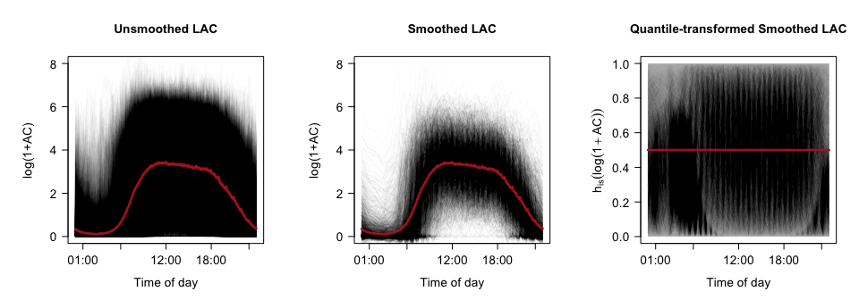

```r
## daily distribution of unsmoothed LAC, smoothed LAC and quantile-transformed smoothed LAC
par(mfrow=c(1,3),las=1, mar=c(5,6,5,2))
textsize <- 1.3
matplot(seq(0,1,len=ncol(data_analysis$act_log_mat)), t(data_analysis$act_log_mat),
        type='l',lty=1,col=rgb(0,0,0,0.02),xlab="Time of day", ylab="log(1+AC)",
        main=paste0("Unsmoothed LAC"), cex.axis=textsize,cex.lab=textsize,cex.main=textsize, xaxt='n', ylim = c(0,8))
axis(1, at=(c(1,6,12,18,23)*60 + 1)/1440, labels=c("01:00","06:00","12:00","18:00","23:00"), cex.axis=textsize)
lines(seq(0,1,len=ncol(data_analysis$act_log_mat)), colMeans(data_analysis$act_log_mat),lwd=2*textsize, col="firebrick", lty=1)

matplot(seq(0,1,len=ncol(data_analysis$act_log_mat_sm)), t(data_analysis$act_log_mat_sm), type='l',lty=1,col=rgb(0,0,0,0.02),xlab="Time of day", ylab="log(1+AC)",
        main=paste0("Smoothed LAC"), cex.axis=textsize,cex.lab=textsize,cex.main=textsize, xaxt='n', ylim = c(0,8))
axis(1, at=(c(1,6,12,18,23)*60 + 1)/1440, labels=c("01:00","06:00","12:00","18:00","23:00"), cex.axis=textsize)
lines(seq(0,1,len=ncol(data_analysis$act_log_mat_sm)), colMeans(data_analysis$act_log_mat_sm),lwd=2*textsize, col="firebrick", lty=1)

matplot(seq(0,1,len=ncol(data_analysis$act_log_mat_sm_q)), t(data_analysis$act_log_mat_sm_q), type='l',lty=1,col=rgb(0,0,0,0.02),xlab="Time of day", ylab=expression(h[is](log(1+AC))),
        main=paste0("Quantile-transformed Smoothed LAC"), cex.axis=textsize,cex.lab=textsize,cex.main=textsize, xaxt='n')
axis(1, at=(c(1,6,12,18,23)*60 + 1)/1440, labels=c("01:00","06:00","12:00","18:00","23:00"), cex.axis=textsize)
lines(seq(0,1,len=ncol(data_analysis$act_log_mat_sm_q)), colMeans(data_analysis$act_log_mat_sm_q),lwd=2*textsize, col="firebrick", lty=1)
```

The curves represent unsmoothed LAC (left), smoothed LAC (middle), and quantile-transformed smoothed LAC (right) of the NHANES participants. From left two panels, we observe a lack of data on the top-left region. This region can not be well-estimated simply because there is little or no data. The quantile-transformed smoothed LAC on the right panel has a much improved coverage on the grid.

## Apply Additive Functional Cox Model to NHANES

In this section, we describe how to apply our model to different functional predictors in NHANES and extract the estimates on area of interest.

### Reproduce Figure 4

In the exploratory plots (Figure 3), we observe no data of high activity counts at night for all NHANES participants. To make this fact clearer, we further draw the density plots of physical activity under different transformations among both deceased and alive individuals. In each panel, we divide the area of interest into certain number of blocks and summarize the number of events and nonevents in each block; see the application section of the paper for details. This is implemented using the `cal.evnt` function below.

```r
## calculate the number of events and nonevents on the grid under each transformation
### function "cal.evnt" returns the number of events and nonevents on the grid for given functional data
#### mat: the functional data
#### n.block.s: number of blocks on s direction, by default 24
#### n.block.x: number of blocks on x direction, by default 20
#### range.x: manually set upper bound of x, if NULL use the range of data
#### lower.x: manually set lower bound of x, by default 0
cal.evnt <- function(mat, n.block.s = 24, n.block.x = 20, range.x = NULL, lower.x = 0){
    ## derive the range of the grid
    range.s <- ncol(mat)
    if(is.null(range.x)){
        range.x <- ceiling(2*max(mat))/2
    }
    ## set range of each sub-domain
    num.sub.s <- n.block.s
    num.sub.x <- n.block.x
    ## get number of value of functional covariates in each sub-domain
    num.event.sub <- matrix(0, nrow = num.sub.s, ncol = num.sub.x)
    num.nonevent.sub <- matrix(0, nrow = num.sub.s, ncol = num.sub.x)
    for(i in 1:num.sub.s){
        ls <- floor((i-1)*range.s/num.sub.s) + 1
        rs <- floor(i*range.s/num.sub.s)
        sub <- as.matrix(mat[,ls:rs])
        for(j in 1:num.sub.x){
            lx <- lower.x + (j-1)*(range.x-lower.x)/num.sub.x
            ux <- lower.x + j*(range.x-lower.x)/num.sub.x
            ind <- c()
            for(k in 1:nrow(sub)){
                if(length(which(sub[k,] >= lx & sub[k,] < ux)) > 0){
                    ind <- c(ind, k)
                }
            }
            num.event.sub[i, j] <- table(data_analysis[ind,]$event)["1"]
            num.nonevent.sub[i, j] <- table(data_analysis[ind,]$event)["0"]
        }
    }
    num.event.sub[which(is.na(num.event.sub))] <- 0
    num.nonevent.sub[which(is.na(num.nonevent.sub))] <- 0

    return(list(num.event.sub = num.event.sub, num.nonevent.sub = num.nonevent.sub,
                range.s = range.s, range.x = range.x, lower.x = lower.x))
}

## unsmoothed LAC
cal.evnt.log <- cal.evnt(data_analysis$act_log_mat, range.x = 8)
## smoothed LAC
cal.evnt.log.sm <- cal.evnt(data_analysis$act_log_mat_sm, range.x = 8)
## quantile-transformed smoothed LAC
cal.evnt.log.sm.q <- cal.evnt(data_analysis$act_log_mat_sm_q)
```

The visualization is achieved through `image.plot()` function in the `fields` package to enhance the constrast between transformations.

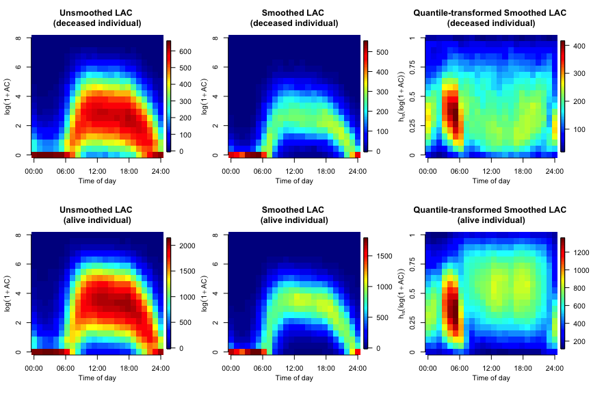

```r
## visualize the number of events and nonevents on the grid
par(mfrow = c(2, 3), mgp = c(2.1, 1, 0), mar = c(4.5, 3.6, 4, 1))

image.plot(cal.evnt.log$num.event.sub, xlab = "Time of day", ylab = expression(log(1 + AC)), main = "Unsmoothed LAC \n(deceased individual)", legend.mar = 8, axes = F)
axis(1, at = seq(0, 1, 0.25), labels = c("00:00", "06:00", "12:00", "18:00", "24:00"))
axis(2, at = seq(0, 1, 0.25), labels = round(seq(0, cal.evnt.log$range.x, length.out = 5), 2))
image.plot(cal.evnt.log.sm$num.event.sub, xlab = "Time of day", ylab = expression(log(1 + AC)), main = "Smoothed LAC \n(deceased individual)", legend.mar = 8, axes = F)
axis(1, at = seq(0, 1, 0.25), labels = c("00:00", "06:00", "12:00", "18:00", "24:00"))
axis(2, at = seq(0, 1, 0.25), labels = round(seq(0, cal.evnt.log.sm$range.x, length.out = 5), 2))
image.plot(cal.evnt.log.sm.q$num.event.sub, xlab = "Time of day", ylab = expression(h[is](log(1 + AC))), main = "Quantile-transformed Smoothed LAC \n(deceased individual)", legend.mar = 8, axes = F)
axis(1, at = seq(0, 1, 0.25), labels = c("00:00", "06:00", "12:00", "18:00", "24:00"))
axis(2, at = seq(0, 1, 0.25), labels = seq(0, 1, 0.25))

image.plot(cal.evnt.log$num.nonevent.sub, xlab = "Time of day", ylab = expression(log(1 + AC)), main = "Unsmoothed LAC \n(alive individual)", legend.mar = 6, axes = F)
axis(1, at = seq(0, 1, 0.25), labels = c("00:00", "06:00", "12:00", "18:00", "24:00"))
axis(2, at = seq(0, 1, 0.25), labels = round(seq(0, cal.evnt.log$range.x, length.out = 5), 2))
image.plot(cal.evnt.log.sm$num.nonevent.sub, xlab = "Time of day", ylab = expression(log(1 + AC)), main = "Smoothed LAC \n(alive individual)", legend.mar = 6, axes = F)
axis(1, at = seq(0, 1, 0.25), labels = c("00:00", "06:00", "12:00", "18:00", "24:00"))
axis(2, at = seq(0, 1, 0.25), labels = round(seq(0, cal.evnt.log.sm$range.x, length.out = 5), 2))
image.plot(cal.evnt.log.sm.q$num.nonevent.sub, xlab = "Time of day", ylab = expression(h[is](log(1 + AC))), main = "Quantile-transformed Smoothed LAC \n(alive individual)", legend.mar = 8, axes = F)
axis(1, at = seq(0, 1, 0.25), labels = c("00:00", "06:00", "12:00", "18:00", "24:00"))
axis(2, at = seq(0, 1, 0.25), labels = seq(0, 1, 0.25))
```

Indeed, quantile transformation substantially improves the estimability on the area of interest, as we see a much better coverage on the right two panels.

### Fit Additive Functional Cox Model

We build a tensor product on the functional covariates when fitting our model using `gam()` function in the `mgcv` package. In the pre-processing we introduce some variables related to calculating the numerical integration of functional term. To be specific, `t_int` is the time indices on $[0,1]$ indicating all time points of observations, `l_int` is the interval length between each two adjacent time points, and `func_cov` is the functional covariates. We are aware of two approaches to ensure identifiability. The first approach first obtains unconstrained estimate then subtracts the corresponding sample mean. The second approach directly impose marginal identifiability constraints when specifying the tensor product, which is implemented by default in this vignette. Both approaches solve the identifiability issue and the estimates are indistinguishable. The comparison of these two approaches is in the supplementary materials of the paper.

Using the second approach, the tensor product is specified as `ti(t_int, func_cov, by=l_int, bs=c("cc","cr"), k=c(Kx,Kt), mc = (FALSE, TRUE))`, where `bs` indicates the type of splines used in each direction, `k` indicates the number of spline basis functions in each direction, and `mc` indicates whether to specify marginal constraints in each direction. The `mc = TRUE` argument on `func_cov` direction coincides with the identifiability constraints discussed in Section 2.3 of the paper.

```r
## smoothed LAC, h_{is} is the identity function
data_analysis$func_cov <- data_analysis$act_log_mat_sm ## specify the functional covariates to use
data_analysis$t_int <- data_analysis$tmat ## t_int helps to integrate the case when models have different tmat and lmat
data_analysis$l_int <- data_analysis$lmat
fit_afc_log_sm <- gam(time_mort ~ Alcohol + Overall_health + PIR + Employed +
                       Age + BMI_cat + SmokeCigs + Race + Education +
                       CHD + Diabetes + CHF + Stroke + MobilityProblem + Cancer +
                       ti(t_int, func_cov, by=l_int, bs=c("cc","cr"), k=c(10,10), mc=c(FALSE,TRUE)), weights=event,
                   data=data_analysis, family=cox.ph())

## quantile-transformed smoothed LAC, h_{is} is the quantile transformation
data_analysis$func_cov <- data_analysis$act_log_mat_sm_q
data_analysis$t_int <- data_analysis$tmat
data_analysis$l_int <- data_analysis$lmat
fit_afc_log_sm_q <- gam(time_mort ~ Alcohol + Overall_health + PIR + Employed +
                        Age + BMI_cat + SmokeCigs + Race + Education +
                        CHD + Diabetes + CHF + Stroke + MobilityProblem + Cancer +
                        ti(t_int, func_cov, by=l_int, bs=c("cc","cr"), k=c(5,5), mc=c(FALSE,TRUE)), weights=event,
                    data=data_analysis, family=cox.ph())
```

We provide the code to fit AFCM using age-specific quantile-transformed smoothed LAC. Note that the `t_int` and `l_int` in this model are different from above models due to different number of observations when performing age-specific quantile-transformation.

```r
#! The code is implementable only if you fit the additive quantile regression model above and derive act_log_sm_qa
#! Implemented in the manuscript, not implemented in this vignette
## age-specific quantile-transformed smoothed LAC
### observation bined by hour in this case
data_analysis$func_cov <- data_analysis$act_log_mat_sm_qa
data_analysis$t_int <- data_analysis$tmat_qa ## tmat_qa is different from other tmat
data_analysis$l_int <- data_analysis$lmat_qa
fit_afc_log_sm_qa <- gam(time_mort ~ Alcohol + Overall_health + PIR + Age + Employed +
                         Age + BMI_cat + SmokeCigs + Race + Education +
                         CHD + Diabetes + CHF + Stroke + MobilityProblem + Cancer +
                         ti(t_int, func_cov, by=l_int, bs=c("cc","cr"), k=c(5,5), mc=c(FALSE,TRUE)), weights=event,
                     data=data_analysis, family=cox.ph())
```

### Reproduce Figure 5

We extract the estimates on a pre-specified grid constructed using `cal_grid()` function with specified range of value of functional covariates (range_x), range of functional domain (range_s), and the length of grid in each direction (grid_length).

```r
## construct the grid (100*100 matrix by default) with specified ranges
### function "cal_grid()" returns grid (grid_coef) with pre-specified range of x and s
#### grid_length: length of grid in each direction, 100 by default
#### range_x: pre-specified upper bound of x, 1 by default
#### range_s: pre-specified upper bound of s, 1 by default
cal_grid <- function(grid_length = 100, range_x = 1, range_s = 1){
    tind_pred <- seq(0, range_s, length.out = grid_length)
    xind_pred <- seq(0, range_x, length.out = grid_length)
    grid_coef <- data.frame(t_int = rep(tind_pred, grid_length),
                            func_cov = rep(xind_pred, each = grid_length),
                            l_int=1)
    return(grid_coef)
}
```

Since several scalar covariates are included, all of them are required to use the `predict()` function to derive the predicted value on the grid of functional term, though their values do not affect the prediction results of functional term. Here we replicate the scalar covariates of the first subject to build the prediction matrix. In applications to different data, the `sample` here should be adjusted based on the covariates used in the model.

```r
## add other variables used in model fitting, required in predict() function
### in practice, we replicate the first row in final grid since it won't incluence estimated functional surface
sample <- data_analysis[1, c("Alcohol", "Overall_health", "PIR", "Age", "Employed", "BMI_cat",
                        "SmokeCigs", "Race", "Education", "CHD", "Diabetes", "CHF", "Stroke",
                        "MobilityProblem", "Cancer")]
```

We next derive the estimates. If we use the first approach to handle identifiability, a post-hoc correction is necessary. However now we directly impose the identifiability constraints in model fitting, so no correction is needed.

```r
## smoothed LAC
grid_coef <- cal_grid(grid_length = 100, range_x = 8, range_s = 1) ## range_x based on maximum of act_log_mat
sample_rep <- do.call("rbind", replicate(nrow(grid_coef), sample, simplify = FALSE))
grid_coef <- cbind(grid_coef, sample_rep)
real_coef_afc_log_sm <- predict(fit_afc_log_sm, newdata = grid_coef, type = 'terms')
real_coef_afc_log_sm <- matrix(real_coef_afc_log_sm[,"ti(t_int,func_cov):l_int"], ncol = sqrt(nrow(grid_coef)), nrow = sqrt(nrow(grid_coef)), byrow = FALSE) # re-organize to matrix form

## quantile-transformed smoothed LAC
grid_coef <- cal_grid(grid_length = 100, range_x = 1, range_s = 1) ## quantile transformation ensures range of x is [0, 1]
sample_rep <- do.call("rbind", replicate(nrow(grid_coef), sample, simplify = FALSE))
grid_coef <- cbind(grid_coef, sample_rep)
real_coef_afc_log_sm_q <- predict(fit_afc_log_sm_q, newdata = grid_coef, type = 'terms')
real_coef_afc_log_sm_q <- matrix(real_coef_afc_log_sm_q[,"ti(t_int,func_cov):l_int"], ncol = sqrt(nrow(grid_coef)), nrow = sqrt(nrow(grid_coef)), byrow = FALSE) # re-organize to matrix form
```

```r
#! The code is implementable only if you fit the additive quantile regression model above and derive act_log_sm_qa
#! Implemented in the manuscript, not in this vignette
## age-specific quantile-transformed smoothed LAC
grid_coef <- cal_grid(grid_length = 100, range_x = 1, range_s = 1)
sample_rep <- do.call("rbind", replicate(nrow(grid_coef), sample, simplify = FALSE))
grid_coef <- cbind(grid_coef, sample_rep)
real_coef_afc_log_sm_qa <- predict(fit_afc_log_sm_qa, newdata = grid_coef, type = 'terms')
real_coef_afc_log_sm_qa <- matrix(real_coef_afc_log_sm_qa[,"ti(t_int,func_cov):l_int"], ncol = sqrt(nrow(grid_coef)), nrow = sqrt(nrow(grid_coef)), byrow = FALSE) # re-organize to matrix form
```

We use the `vis_surf()` function to visualize the estimates, which is essentially a wrapper of `ggplot2`.

```r
### function "vis_surf()" returns the visualization of functional surface using ggplot2 package
#### coef: the matrix to visualize
#### simulation: indicate whether the plot is for application (FALSE) or simulation (TRUE)
#### transformation: indicate whether the functional covariates are transformed (TRUE) or not (FALSE)
#### range_x: the upper bound of functional value domain
#### range_s: the upper bound of functional domain
#### trans_name: name of the transformation
vis_surf <- function(coef, simulation = FALSE, transformation = TRUE, range_x = 1, range_s = 1,
                     trans_name = "smoothed LAC"){
    coef_plot <- melt(coef) # re-organize to plot form
    grid_length <- nrow(coef) ## length of grid in each direction
    ## when the surface is from real data, x axis is time of a day, y axis is transformed AC
    if(simulation == FALSE){
        if(transformation == TRUE){
            name_y <- expression(h[is](log(1 + AC)))
        }else{
            name_y <- expression(log(1 + AC))
        }
        surf <- ggplot(coef_plot, aes(Var1,Var2, fill = value)) +
            geom_raster() +
            scale_fill_gradientn(colours=c("blue3", "#FFFFFF", "#F67F7F", "#FF0000"), name = expression(hat(F)(.,.))) +
            ggtitle(trans_name) +
            scale_x_continuous(name = "Time of day",
                               breaks = c(1, floor(0.25 * grid_length), floor(0.5 * grid_length), floor(0.75 * grid_length), grid_length),
                               labels = c("00:00","06:00", "12:00", "18:00", "24:00")) +
            scale_y_continuous(name = name_y,
                               breaks = floor(seq(0, floor(range_x), length.out = 5) / range_x * grid_length),
                               labels = seq(0, floor(range_x), length.out = 5)) +
            theme_minimal() +
            theme(plot.title = element_text(face = "bold", size = 15, hjust = 0.5))
    }else{ ## when the surface is from simulated data, x axis is the functional domain, y axis is the functional value domain,
        surf <- ggplot(coef_plot, aes(Var1,Var2, fill = value)) +
            geom_raster() +
            scale_fill_gradientn(colours = c("blue3", "#FFFFFF", "red2"), name = expression(hat(F)(.,.))) +
            ggtitle(trans_name) +
            scale_x_continuous(name = "Functional domain",
                               breaks = floor(seq(0, floor(range_s), length.out = 6) / range_s * grid_length),
                               labels = seq(0, floor(range_s), length.out = 6)) +
            scale_y_continuous(name = "Value of functional covariate",
                               breaks = floor(seq(0, floor(range_x), length.out = 6) / range_x * grid_length),
                               labels = seq(0, floor(range_x), length.out = 6)) +
            theme_minimal() +
            theme(plot.title = element_text(face = "bold", size = 15, hjust = 0.5))
    }
    return(surf)
}

## Estimates from smoothed LAC
real_surf_afc_log_sm <- vis_surf(coef = real_coef_afc_log_sm, transformation = FALSE, range_x = 8, trans_name = "Estimates from smoothed LAC")
## Estimates from quantile-transformed smoothed LAC
real_surf_afc_log_sm_q <- vis_surf(coef = real_coef_afc_log_sm_q, transformation = TRUE, range_x = 1, trans_name = "Estimates from quantile-transformed smoothed LAC")
```

```r
#! The code is implementable only if you fit the additive quantile regression model above and derive act_log_sm_qa
#! Implemented in the manuscript, not implemented in this vignette
## smoothed and age-specific quantile-transformed AC
real_surf_afc_log_sm_qa <- vis_surf(coef = real_coef_afc_log_sm_qa, transformation = TRUE, range_x = 1, trans_name = "Estimates from age-specific quantile-transformed\n smoothed LAC")
```

```r
### function "vis_stratified()" returns the visualization of functional surface from stratified analysis
#### period: "night" or "day"
#### grid_length: length of grid in each direction
vis_stratified <- function(period, grid_length = 100){
    if(period == "night"){
        nt <- 480
        ind <- 1:480
        period <- "Night"
        time.break <- c(1, floor(0.5 * grid_length), grid_length)
        time.label <- c("00:00","04:00", "08:00")
        legend.pos <- "none"
    }else if(period == "day"){
        nt <- 960
        ind <- 481:1440
        period <- "Daytime"
        time.label <- c("08:00", "12:00", "16:00", "20:00", "24:00")
        time.break <- c(1, floor(0.25 * grid_length), floor(0.5 * grid_length), floor(0.75 * grid_length), grid_length)
        legend.pos <- "right"
    }
    pctl <- 0.9
    data_analysis$func_cov   <- I(fpca.face(unclass(data_analysis$act_log_mat[,ind]))$Yhat)
    name_y <- expression(log(1 + AC))
    title <- paste0(period)

    ## fit AFCM
    data_analysis$t_int <- I(matrix(seq(0, 1, length.out = nt), ncol=nt, nrow=nrow(data_analysis), byrow=TRUE))
    data_analysis$l_int <- I(matrix(1/nt, ncol=nt, nrow=nrow(data_analysis)))
    fit_afc_period <- gam(time_mort ~ Alcohol + Overall_health + PIR + Employed +
                              Age + BMI_cat + SmokeCigs + Race + Education +
                              CHD + Diabetes + CHF + Stroke + MobilityProblem + Cancer +
                              ti(t_int, func_cov, by=l_int, bs=c("cr","cr"), k=c(5,5), mc = c(FALSE, TRUE)),
                          weights=event, data=data_analysis, family=cox.ph())

    ## extract estimates
    sample <- data_analysis[1, c("Alcohol", "Overall_health", "PIR", "Age", "Employed", "BMI_cat",
                                 "SmokeCigs", "Race", "Education", "CHD", "Diabetes", "CHF", "Stroke",
                                 "MobilityProblem", "Cancer")]
    grid_coef <- cal_grid(grid_length = 100, range_x = quantile(data_analysis$func_cov, pctl), range_s = 1)
    sample_rep <- do.call("rbind", replicate(nrow(grid_coef), sample, simplify = FALSE))
    grid_coef <- cbind(grid_coef, sample_rep)
    real_coef_afc_period <- predict(fit_afc_period, newdata = grid_coef, type = 'terms')
    real_coef_afc_period <- matrix(real_coef_afc_period[,"ti(t_int,func_cov):l_int"], ncol = sqrt(nrow(grid_coef)), nrow = sqrt(nrow(grid_coef)), byrow = FALSE) # re-organize to matrix form

    ## plot the estimates
    grid_length <- nrow(real_coef_afc_period)
    range_x = quantile(data_analysis$func_cov, pctl)
    real_surf_afc_period <- ggplot(melt(real_coef_afc_period), aes(Var1,Var2, fill = value)) +
        geom_raster() +
        scale_fill_gradientn(colours=c("blue3", "blue3", "#FFFFFF", "#FF0000"), name = expression(hat(F)(.,.))) +
        ggtitle(title) +
        scale_x_continuous(name = "Time of day",
                           breaks = time.break,
                           labels = time.label) +
        scale_y_continuous(name = name_y,
                           breaks = floor(seq(0, range_x, length.out = 5) / range_x * grid_length),
                           labels = round(seq(0, round(range_x, 2), length.out = 5), 2)) +
        theme_minimal() +
        theme(plot.title = element_text(face = "bold", size = 15, hjust = 0.5),
              legend.position = legend.pos)
    return(real_surf_afc_period)
}

## stratified analysis by day and night
real_surf_afc_log_night <- vis_stratified(period = "night")
real_surf_afc_log_day <- vis_stratified("day")
```

Figure 5 except bottom-right panel is shown below. If the age-specific quantile-transformed smoothed LAC is derived and fitted in the model in previous steps, the entire plot can be reproduced.

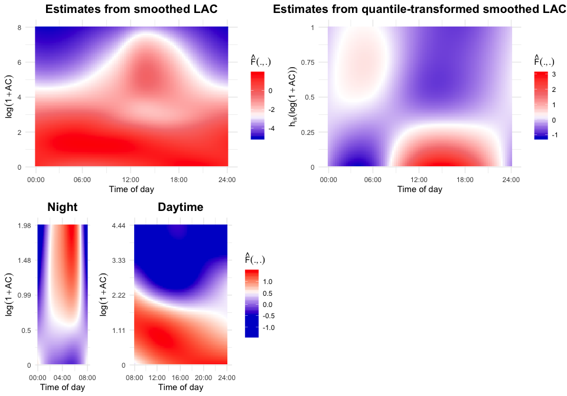

```r
grid.arrange(grobs = list(real_surf_afc_log_sm, real_surf_afc_log_night, real_surf_afc_log_day,
                          real_surf_afc_log_sm_q),
             layout_matrix = rbind(c(1,1,1,4,4,4),
                                   c(2,3,3,NA,NA,NA)))
```

## Calculate cross-validated c-index and Brier’s score

To evaluate the predictive performance, we calculate and compare the cross-validated c-index and Brier’s score between additive functional Cox model (AFCM) and linear functional Cox model (LFCM). For each functional model, we use three physical activity measures, including unsmoothed LAC (unsmoothed), smoothed LAC (smoothed), and quantile-transformed smoothed LAC (smoothed + quantile). In addition, a Cox proportional hazard model (Cox PHM) is fit as the baseline using the average smoothed LAC of each individual as a scalar predictor. In total there are $2\times 3+1 = 7$ combinations. Number of folds is chosen to be 10 to balance the amount of test data and the total number of validations. The c-index and Brier’s score of each model are stored in `iAUC_*` and `iBrier_*` respectively, where "*" indicates the exact model.

```r
# cross validated c-index and Brier's score for each model
## introduce variables in the cross validation
set.seed(135)
n_folds <- 10 # number of folds
### variables that store the c-index and Brier's score in each calculation
iAUC_afc <- iAUC_afc_sm <- iAUC_afc_sm_q <- iAUC_lfc <- iAUC_lfc_sm <- iAUC_lfc_sm_q <- iAUC_cph <- rep(0, n_folds)
iBrier_afc <- iBrier_afc_sm <- iBrier_afc_sm_q <- iBrier_lfc <- iBrier_lfc_sm <- iBrier_lfc_sm_q <- iBrier_cph <- rep(0, n_folds)
### use "createFolds" function from "caret" package to divide real data into n_folds folds
fold <- createFolds(data_analysis$time_mort, k = n_folds, list = FALSE)

### function "cal_c()" calculates Concordance using concordant vs discordant pairs empricical estimator
## marker = \hat\eta_i
## Stime = survival times
## status = event status (0 = censored, 1 = event)
cal_c <- function(marker, Stime, status){
    utimes <- sort(unique(Stime[status==1]))
    num <- denom <- 0
    for(ut in seq_along(utimes)){
        ## current time
        ti    <- utimes[ut]
        ## subjects who experienced an event at current time
        inx_i <- which(Stime == ti & status==1)
        ## subjects with observed times beyond event current time
        inx_j <- which(Stime > ti)
        ## number of "cases" and "controls" at time current time
        n_case_t    <- length(inx_i)
        n_control_t <- length(inx_j)
        for(i in seq_along(inx_i)){
            num   <- num + sum( (marker[inx_j] > marker[inx_i[i]] ) ) + 0.5*sum(marker[inx_j] == marker[inx_i[i]])
        }
        denom <- denom + n_case_t*n_control_t
    }
    1-num/denom
}

### function "cal_stime()" returns the survival times estimates on the test data in cross-validated prediction
cal_stime <- function(fit, tmax = 10, nt_pred = 1000, tgrid_sim = seq(0, 10, len=1000)){
    ## calculate estimated baseline hazard
    t0 <- rev(fit$family$data$tr)
    H0_hat <- rev(fit$family$data$h) ## estimate for the baseline cumulative hazard function \int_0^t \lambda_0(s)ds
    H0_fit <- gam(H0_hat ~ s(t0, pc = 0)-1) ## smooth the cumulative hazard
    ## evaluate smoothed H0 on fine grid
    tgrid_sim <- seq(0, tmax, len=nt_pred) ## potential grid of time points to simulate from
    H0_prd <- pmax(0, predict(H0_fit, newdata = data.frame(t0 = tgrid_sim))) ## truncate cumulative hazard at 0
    ## estimate eta from estimated functional surface of real data
    eta_i <- matrix(predict(fit, test_data), ncol = 1)
    ## calcualte survival times
    S_i <- exp(-(exp(eta_i) %*% H0_prd))
    return(S_i)
}

### function "cal_Brier()" calculates Brier's score under right censored survival setting
cal_Brier <- function(S, Stime, status, tgrid = seq(0, 10, len=1000)){
    iBrier <- 0
    utimes <- sort(unique(Stime[status == 1]))
    if(max(utimes) == 10){
        utimes <- utimes[-length(utimes)]
    }
    Brier.t <- rep(NA, length(utimes))
    for(ut in seq_along(utimes)){
        ## current time
        ti <- utimes[ut]
        ## subjects with observed times beyond event current time
        inx_j <- which(Stime > ti)
        ## subjects who experienced an event before or at current time
        inx_i <- which(Stime <= ti & status==1)
        ## extract survival probability of all subjects at this time
        surv.prob <- S[,max(which(tgrid <= ti))]
        tmp <- 0
        for(i in 1:nrow(S)){
            G <- 1
            if(i %in% inx_j){
                if(max(which(ut_test_censor < ti)) > 0){
                    G <- KM_test_censor[max(which(ut_test_censor < ti))]
                }
                tmp <- tmp + (1-surv.prob[i])^2/G
            }else if(i %in% inx_i){
                if(max(which(ut_test_censor < Stime[i])) > 0){
                    G <- KM_test_censor[max(which(ut_test_censor < Stime[i]))]
                }
                tmp <- tmp + (0-surv.prob[i])^2/G
            }
        }
        Brier.t[ut] <- tmp/nrow(S)
        if(ut == 1){
            iBrier <- iBrier + 0.5*utimes[ut]*Brier.t[ut]
        }else{
            iBrier <- iBrier + Brier.t[ut]*(utimes[ut] - utimes[ut-1])
        }
    }
    iBrier <- iBrier/max(utimes)
    return(iBrier)
}

## run cross validation
for(k in 1:n_folds){
    ## split train and test data
    train_data <- data_analysis[-which(fold == k),]
    test_data <- data_analysis[which(fold == k),]

    ## survival time and status
    time_test   <- test_data$time_mort
    event_test <- test_data$event
    time_train   <- train_data$time_mort
    event_train <- train_data$event

    ## get unique ordered survival times
    ut_train <- unique(time_train[event_train == 1])
    ut_train <- ut_train[order(ut_train)]
    ut_test <- unique(time_test[event_test == 1])
    ut_test <- ut_test[order(ut_test)]

    ## get KM estimates of survival function for train data
    KM_train <- unique(survfit(Surv(time_train,event_train)~1)$surv)
    ## get KM estimates of survival function for test data where test and training overlap
    ## impute linearly on the log scale for survival times which are not in the training dataset
    KM_test  <- rep(NA, length(ut_test))
    for(i in seq_along(ut_test)){
        ## if test data survival time less than the minimum observed event time in the training dataset
        ## impute survival time on the linearly log scale
        if(ut_test[i] < min(ut_train)){
            KM_test[i] <- exp(log(1) - (log(1) - log(KM_train[1])) / (ut_train[1]-0) * (ut_test[1]-0))
        }
        ## if test data survival time within the observed range of event times in the training dataset,
        ## either use the KM estimate (if the training time is in the test times), or impute linearly on the log scale
        if(ut_test[i] >= min(ut_train) & ut_test[i] < max(ut_train)){
            inx_l <- max(which(ut_train <= ut_test[i]))
            inx_r <- min(which(ut_train > ut_test[i]))
            st_l <- KM_train[inx_l]
            st_r <- KM_train[inx_r]
            t_l <- ut_train[inx_l]
            t_r <- ut_train[inx_r]
            KM_test[i] <- exp(log(st_l) - (log(st_l) - log(st_r))/(t_r -t_l)  * (ut_test[i] - t_l))
        }
        ## if the test data survival time is beyond the observe range of event times in the training dataset,
        ## use the last observed survival probability
        if(ut_test[i] >= max(ut_train)){
            KM_test[i] <- min(KM_train)
        }
    }
```

```r
    ## derive the KM estimate of the censoring time
    ut_train_censor <- unique(time_train[event_train == 0])
    ut_train_censor <- ut_train_censor[order(ut_train_censor)]
    ut_test_censor <- unique(time_test[event_test == 0])
    ut_test_censor <- ut_test_censor[order(ut_test_censor)]
    ## get KM estimates of censoring time for train data
    KM_train_censor <- unique(survfit(Surv(time_train,1-event_train)~1)$surv)
    ## get KM estimates of censoring time for test data where test and training overlap
    ## impute linearly on the log scale for survival times which are not in the training dataset
    KM_test_censor  <- rep(NA, length(ut_test_censor))
    for(i in seq_along(ut_test_censor)){
        ## if test data survival time less than the minimum observed event time in the training dataset
        ## impute survival time on the linearly log scale
        if(ut_test_censor[i] < min(ut_train_censor)){
            KM_test_censor[i] <- exp(log(1) - (log(1) - log(KM_train_censor[1])) / (ut_train_censor[1]-0) * (ut_test_censor[1]-0))
        }
        ## if test data survival time within the observed range of event times in the training dataset,
        ## either use the KM estimate (if the training time is in the test times), or impute linearly on the log scale
        if(ut_test_censor[i] >= min(ut_train_censor) & ut_test_censor[i] < max(ut_train_censor)){
            inx_l <- max(which(ut_train_censor <= ut_test_censor[i]))
            inx_r <- min(which(ut_train_censor > ut_test_censor[i]))
            st_l <- KM_train_censor[inx_l]
            st_r <- KM_train_censor[inx_r]
            t_l <- ut_train_censor[inx_l]
            t_r <- ut_train_censor[inx_r]
            KM_test_censor[i] <- exp(log(st_l) - (log(st_l) - log(st_r))/(t_r -t_l)  * (ut_test_censor[i] - t_l))
        }
        ## if the test data survival time is beyond the observe range of event times in the training dataset,
        ## use the last observed survival probability
        if(ut_test_censor[i] >= max(ut_train_censor)){
            KM_test_censor[i] <- min(KM_train_censor)
        }
    }

    ## fit each model using train data
    ### AFCM
    fit_afc_cv <- gam(time_mort ~ Alcohol + Overall_health + PIR + Age + Employed +
                          Age + BMI_cat + SmokeCigs + Race + Education +
                          CHD + Diabetes + CHF + Stroke + MobilityProblem + Cancer +
                          ti(tmat, act_log_mat, by=lmat, bs=c("cc","cr"), k=c(5,5), mc = c(FALSE, TRUE)), weights=event, data=train_data, family=cox.ph())

    fit_afc_sm_cv <- gam(time_mort ~ Alcohol + Overall_health + PIR + Age + Employed +
                             Age + BMI_cat + SmokeCigs + Race + Education +
                             CHD + Diabetes + CHF + Stroke + MobilityProblem + Cancer +
                             ti(tmat, act_log_mat_sm, by=lmat, bs=c("cc","cr"), k=c(5,5), mc = c(FALSE, TRUE)), weights=event, data=train_data, family=cox.ph())

    fit_afc_sm_q_cv <- gam(time_mort ~ Alcohol + Overall_health + PIR + Age + Employed +
                               Age + BMI_cat + SmokeCigs + Race + Education +
                               CHD + Diabetes + CHF + Stroke + MobilityProblem + Cancer +
                               ti(tmat, act_log_mat_sm_q, by=lmat, bs=c("cc","cr"), k=c(5,5), mc = c(FALSE, TRUE)), weights=event, data=train_data, family=cox.ph())

    ### LFCM
    fit_lfc_cv <- gam(time_mort ~ Alcohol + Overall_health + PIR + Age + Employed +
                          Age + BMI_cat + SmokeCigs + Race + Education +
                          CHD + Diabetes + CHF + Stroke + MobilityProblem + Cancer +
                          s(tmat, by = lmat * act_log_mat, bs="cc", k = 10), weights=event, data=train_data, family=cox.ph())

    fit_lfc_sm_cv <- gam(time_mort ~ Alcohol + Overall_health + PIR + Age + Employed +
                             Age + BMI_cat + SmokeCigs + Race + Education +
                             CHD + Diabetes + CHF + Stroke + MobilityProblem + Cancer +
                             s(tmat, by = lmat * act_log_mat_sm, bs="cc", k = 10), weights=event, data=train_data, family=cox.ph())

    fit_lfc_sm_q_cv <- gam(time_mort ~ Alcohol + Overall_health + PIR + Age + Employed +
                               Age + BMI_cat + SmokeCigs + Race + Education +
                               CHD + Diabetes + CHF + Stroke + MobilityProblem + Cancer +
                               s(tmat, by = lmat * act_log_mat_sm_q, bs="cc", k = 10), weights=event, data=train_data, family=cox.ph())

    ### Cox proportional hazard model
    fit_cph_cv <- gam(time_mort ~ Alcohol + Overall_health + PIR + Age + Employed +
                          Age + BMI_cat + SmokeCigs + Race + Education +
                          CHD + Diabetes + CHF + Stroke + MobilityProblem + Cancer +
                          act_log_mat_ave, weights=event, data=train_data, family=cox.ph())

    ## obtain estimated log hazard (excluding baseline hazard)
    ### afc
    eta_afc_cv <- rowSums(predict(fit_afc_cv, test_data, type = "terms"))
    eta_afc_sm_cv <- rowSums(predict(fit_afc_sm_cv, test_data, type = "terms"))
    eta_afc_sm_q_cv <- rowSums(predict(fit_afc_sm_q_cv, test_data, type = "terms"))
    ### lfc
    eta_lfc_cv <- rowSums(predict(fit_lfc_cv, test_data, type="terms"))
    eta_lfc_sm_cv <- rowSums(predict(fit_lfc_sm_cv, test_data, type="terms"))
    eta_lfc_sm_q_cv <- rowSums(predict(fit_lfc_sm_q_cv, test_data, type="terms"))
    ### cph
    eta_cph_cv <- rowSums(predict(fit_cph_cv, test_data, type="terms"))

    ## derive cross-validated c-index
    iAUC_afc[k] <- cal_c(marker = eta_afc_cv, Stime = time_test, status = event_test)
    iAUC_afc_sm[k] <- cal_c(marker = eta_afc_sm_cv, Stime = time_test, status = event_test)
    iAUC_afc_sm_q[k] <- cal_c(marker = eta_afc_sm_q_cv, Stime = time_test, status = event_test)
    iAUC_lfc[k] <- cal_c(marker = eta_lfc_cv, Stime = time_test, status = event_test)
    iAUC_lfc_sm[k] <- cal_c(marker = eta_lfc_sm_cv, Stime = time_test, status = event_test)
    iAUC_lfc_sm_q[k] <- cal_c(marker = eta_lfc_sm_q_cv, Stime = time_test, status = event_test)
    iAUC_cph[k] <- cal_c(marker = eta_cph_cv, Stime = time_test, status = event_test)
```

```r
    ## calculate the cross-validated brier score
    S_afc_cv <- cal_stime(fit = fit_afc_cv)
    S_afc_sm_cv <- cal_stime(fit = fit_afc_sm_cv)
    S_afc_sm_q_cv <- cal_stime(fit = fit_afc_sm_q_cv)
    S_lfc_cv <- cal_stime(fit = fit_lfc_cv)
    S_lfc_sm_cv <- cal_stime(fit = fit_lfc_sm_cv)
    S_lfc_sm_q_cv <- cal_stime(fit = fit_lfc_sm_q_cv)
    S_cph_cv <- cal_stime(fit = fit_cph_cv)

    tgrid_sim <- seq(0, 10, len=1000)
    iBrier_afc[k] <- cal_Brier(S_afc_cv, Stime = time_test, status = event_test, tgrid = tgrid_sim)
    iBrier_afc_sm[k] <- cal_Brier(S_afc_sm_cv, Stime = time_test, status = event_test, tgrid = tgrid_sim)
    iBrier_afc_sm_q[k] <- cal_Brier(S_afc_sm_q_cv, Stime = time_test, status = event_test, tgrid = tgrid_sim)
    iBrier_lfc[k] <- cal_Brier(S_lfc_cv, Stime = time_test, status = event_test, tgrid = tgrid_sim)
    iBrier_lfc_sm[k] <- cal_Brier(S_lfc_sm_cv, Stime = time_test, status = event_test, tgrid = tgrid_sim)
    iBrier_lfc_sm_q[k] <- cal_Brier(S_lfc_sm_q_cv, Stime = time_test, status = event_test, tgrid = tgrid_sim)
    iBrier_cph[k] <- cal_Brier(S_cph_cv, Stime = time_test, status = event_test, tgrid = tgrid_sim)
}
```

The result reported in Table 1 of the paper is shown below. Additive functional Cox model (AFCM) outperforms linear functional Cox model (LFCM) and baseline model (Cox PHM) with respect to the predictive performance. The differences within AFCM is subtle, though quantile transformation substantially enhances the interpretation.

```r
print(round(apply(cbind(iAUC_afc, iAUC_afc_sm, iAUC_afc_sm_q,
                        iAUC_lfc, iAUC_lfc_sm, iAUC_lfc_sm_q, iAUC_cph), 2, mean), 3))
```

```
##      iAUC_afc   iAUC_afc_sm iAUC_afc_sm_q      iAUC_lfc   iAUC_lfc_sm
##         0.795         0.795         0.793         0.791         0.791
## iAUC_lfc_sm_q      iAUC_cph
##         0.791         0.791
```

```r
print(round(apply(cbind(iBrier_afc, iBrier_afc_sm, iBrier_afc_sm_q,
                        iBrier_lfc, iBrier_lfc_sm, iBrier_lfc_sm_q, iBrier_cph), 2, mean), 4))
```

```
##      iBrier_afc   iBrier_afc_sm iBrier_afc_sm_q      iBrier_lfc   iBrier_lfc_sm
##          0.0751          0.0751          0.0753          0.0754          0.0754
## iBrier_lfc_sm_q      iBrier_cph
##          0.0753          0.0758
```

## Simulation

### Simulation framework

The simulation framework shown here consists of two parts: the simulation of functional covariates, and the simulation of survival data. The simulation of functional covariates is based on functional principal component analysis (FPCA). Denote $\mu(s) = E(X(s))$, the simulated functional covariate $\tilde{X}_i(s)$ is derived as
$$\tilde{X}_i(s) = \hat{\mu}(s) + \sum_{j = 1}^M \sqrt{\hat{\lambda}_j} e_{ij} \hat{\psi}_j(s),$$
where $e_{ij}$ are i.i.d. $N(0,1)$ random variables. The mean, $\hat{\mu}(s)$, eigenvalues, $\hat{\lambda}_j$, and eigenfunctions, $\hat{\psi}_j(s)$, are estimated using `fpca.face()` function in the `refund` package. The `sim_func_cov()` function below implements this idea, and returns simulated functional covariates as a matrix.

```r
## simulate functional covariate from real data
### function "sim_func_cov" simulate functional covariates using FPCA
#### real_func_cov: the matrix to simulate functional covariates from
#### N: number of subjects to simulate
sim_func_cov <- function(real_func_cov, N){
    ## FPCA
    fit_fpca <- fpca.face(unclass(real_func_cov))

    ## extract estimated eigenfunctions/eigenvalues
    phi <- fit_fpca$efunctions
    lambda <- fit_fpca$evalues
    K <- length(fit_fpca$evalues)

    ## simulate random coefficients
    theta <- matrix(rnorm(N*K), nrow=N, ncol=K)  # generate independent standard normals
    theta <- theta %*% diag(sqrt(lambda))        # scale to have appropriate variance
    X_new <- theta %*% t(phi)                    # simulate new functions
    X_new <- X_new + t(fit_fpca$mu %o% rep(1,N))      # add back in the mean function
    return(X_new)
}
```

The procedure to simulate survival data is organized as follows: (1) derive the estimated cumulative baseline hazard function $\tilde{\Lambda}_0(t)$; (2) derive the estimated linear predictor $\tilde{\eta}_i$; (3) derive the estimated survival function $\tilde{S}_i(t)$; (4) simulate survival time $\tilde{T}_i$ from $\tilde{S}_i(t)$; and (5) simulate censoring time $\tilde{C}_i$ from the empirical distribution of censoring times in the NHANES data to control censoring rate.

The key component here is to derive the estimated linear predictor $\tilde{\eta}_i$ in step (2). Two simulation components are considered. In the first component, the function $F(\cdot, \cdot)$ is estimated from real data, implemented through `sim_surv()` function below. The simulated survival data, combined with the transformed simulated functional covariates, are returned as a data frame.

```r
## simulate survival data from real data (NHANES here, but can be any types of functional data)
### function "sim_surv()" simulate survival data using estimated functional surface from real data
#### fit: the fitted model used to estimate cumulative hazard
#### N: number of subjects to simulate
#### X: functional covariates used to predict eta
#### tmax: upper bound of time points to simulate from
#### time_mort: time to event information from real data
#### event: event status information from real data
#### nt_pred: number of potential survival times
sim_surv <- function(fit, N, X, tmax, time_mort, event, nt_pred = 1000){
    ## calculate estimated baseline hazard
    t0 <- rev(fit$family$data$tr)
    H0_hat <- rev(fit$family$data$h) ## estimate for the baseline cumulative hazard function \int_0^t \lambda_0(s)ds
    H0_fit <- scam(H0_hat ~ s(t0, bs = "mpi")-1) ## smooth the cumulative hazard
    ## evaluate smoothed H0 on fine grid
    tgrid_sim <- seq(0, tmax, len=nt_pred) ## potential grid of time points to simulate from
    H0_prd <- pmax(0, predict(H0_fit, newdata = data.frame(t0 = tgrid_sim))) ## truncate cumulative hazard at 0
    H0_prd[1] <- 0

    ## combine functional covariates with necessary elements in model fitting
    nt <- ncol(X)
    tind <- seq(0, 1, length.out = nt)
    data_sim <- data.frame(func_cov = I(X),
                           l_int = I(matrix(1/nt, ncol = nt, nrow = N)),
                           t_int = I(matrix(tind, ncol = nt, nrow = N, byrow = TRUE)))

    ## estimate eta from estimated functional surface of real data
    eta_i <- predict(fit, newdata = data_sim, type = 'terms')

    ## calcualte survival times
    S_i <- exp(-(exp(eta_i) %*% H0_prd))
    U   <- runif(N)
    Ti  <- rep(NA, N)
    for(i in 1:N){
        if(all(S_i[i,] > U[i])){
            Ti[i] <- max(tgrid_sim) + 1
        } else {
            Ti[i] <- tgrid_sim[min(which(S_i[i,] < U[i]))]
        }
    }

    ## simulate censoring times from empirical distribution
    C_i <- sample(time_mort[event == 0], size=N, replace=TRUE)

    ## create simulated censoring indicator based on "true" event time S_i and censoring time C_i
    Ti_obs <- pmin(C_i, Ti)
    di <- as.numeric(Ti <= C_i)

    ## combine the simulated survival data in a data frame
    data_sim <- data.frame(data_sim, time_mort = Ti_obs, event=di)
    data_sim$act_log_mat_ave <- rowSums(data_sim$func_cov) / ncol(data_sim$func_cov)

    return(data_sim)
}
```

In the second component, the functional surface $F(\cdot, \cdot)$ is pre-specified, implemented through `sim_surv_F()` function. We consider four different forms of $F(\cdot, \cdot)$: (1) $F(s, x) = 2x$ (`model_type = "const"`); (2) $F(s, x) = xs$ (`model_type = "linear"`); (3) $F(s, x) = x^3 s$ (`model_type = "nonlinear1"`); and (4) $F(s, x) = \sin{xs}$ (`model_type = "nonlinear2"`). This function also returns a data frame containing both the transformed simulated functional covariates and simulated survival data.

```r
## simulate survival data with pre-specified F(.,.)
### function "sim_surv_F()" simulate survival data using pre-specified F(.,.)
#### fit: the model used to estimate cumulative hazard
#### N: number of subjects to simulate
#### tmax: upper bound of time points to simulate from
#### time_mort: time to event from real data
#### event: event status from real data
#### nt_pred: number of potential survival times
#### model: name of the specified F(.,.)
#### range_x: upper bound of functional value domain, 1 by default
#### range_s: upper bound of functional domain, 1 by default
sim_surv_F <- function(fit, N, tmax, time_mort, event, nt_pred = 1000, model = "linear", range_x = 1, range_s = 1){
    ## calculate estimated baseline hazard
    t0 <- rev(fit$family$data$tr)
    H0_hat <- rev(fit$family$data$h) ## estimate for the baseline cumulative hazard function \int_0^t \lambda_0(s)ds
    H0_fit <- scam(H0_hat ~ s(t0, bs = "mpi")-1)
    ## evaluate smoothed H0 on fine grid
    tgrid_sim <- seq(0, tmax, len=nt_pred) ## potential grid of time points to simulate from
    H0_prd <- pmax(0, predict(H0_fit, newdata = data.frame(t0 = tgrid_sim))) ## truncate cumulative hazard at 0
    H0_prd[1] <- 0

    ## define pre-specified functional coefficient surface F(.,.), labeled as beta
    if(model == "linear"){
        beta <- function(X, s) X*s
    }else if(model == "const"){
        beta <- function(X, s) X*2
    }else if(model == "nonlinear1"){
        beta <- function(X, s) (X^3)*s
    }else if(model == "nonlinear2"){
        beta <- function(X, s) sin(X*s)
    }

    ## simulate functional covariate from FPCA
    X_new <- sim_func_cov(data_analysis$act_log_mat_sm, N)
    X_new <- I(apply(X_new, 2,function(y) ecdf(y)(y))) * range_x * 2
    X_new <- sweep(X_new, 2, colMeans(X_new)) ## mean center simulated functional covariates

    ## combine functional covariates with necessary elements in model fitting
    nt <- ncol(X_new)
    tind <- seq(0, range_s, length.out = nt)
    data_sim <- data.frame(func_cov = I(X_new),
                           l_int = I(matrix(1/nt, ncol = nt, nrow = N)),
                           t_int = I(matrix(tind, ncol = nt, nrow = N, byrow = TRUE)))

    # calculate eta_i using numerical intergration given pre-specified F
    eta_i <- as.matrix(apply(X_new, 1, function(x) sum(beta(X=x, s=tind))/nt), ncol = 1)

    ## calcualte survival times
    S_i <- exp(-(exp(eta_i) %*% H0_prd))
    U   <- runif(N)
    Ti  <- rep(NA, N)
    for(i in 1:N){
        if(all(S_i[i,] > U[i])){
            Ti[i] <- max(tgrid_sim) + 1
        } else {
            Ti[i] <- tgrid_sim[min(which(S_i[i,] < U[i]))]
        }
    }

    ## simulate censoring times from empirical distribution
    C_i <- sample(time_mort[event == 0], size=N, replace=TRUE)

    ## Create simulated censoring indicator based on "true" event time S_i and censoring time C_i
    Ti_obs <- pmin(C_i, Ti)
    di <- as.numeric(Ti <= C_i)

    ## combine the simulated survival data in a data frame
    data_sim <- data.frame(data_sim, time_mort = Ti_obs, event=di)
    data_sim$act_log_mat_ave <- rowSums(data_sim$func_cov) / ncol(data_sim$func_cov)

    return(data_sim)
}
```

Some functions introduced in the application section are slightly modified for simulation use.

```r
### a similar function to "cal_grid", add variables to flexibly control the boundary of the grid
cal_grid_sim <- function(grid_length = 100, x_lo = -1, x_up = 1, s_lo = 0, s_up = 2){
    tind_pred <- seq(s_lo, s_up, length.out = grid_length)
    xind_pred <- seq(x_lo, x_up, length.out = grid_length)
    grid_coef <- data.frame(t_int = rep(tind_pred, grid_length),
                            func_cov = rep(xind_pred, each = grid_length),
                            l_int=1)
    return(grid_coef)
}

### a similar function to "vis_surf", modify variables to improve plotting efficiency in the simulation
vis_surf_sim <- function(coef, x_lo = -1, x_up = 1, s_lo = 0, s_up = 2, name, lb = 0, ub = 1, fontsize = 12){
  coef_plot <- melt(coef) # re-organize to plot form
  grid_length <- nrow(coef)

  bound <- c(lb, ub)
  color <- c("blue3", "#FFFFFF", "red2")
  surf <- ggplot(coef_plot, aes(Var1,Var2, fill = value)) +
    geom_raster() +
    scale_fill_gradientn(colours=color, name = expression(hat(F)(.,.)), limits = bound) +
    ggtitle(name) +
    scale_x_continuous(name = "Functional domain",
                       breaks = floor(seq(0, grid_length, length.out = 6)),
                       labels = seq(s_lo, s_up, length.out = 6)) +
    scale_y_continuous(name = "Value of functional covariate",
                       breaks = floor(seq(0, grid_length, length.out = 6)),
                       labels = seq(x_lo, x_up, length.out = 6)) +
    theme_minimal() +
    theme(plot.title = element_text(size = fontsize, face = "bold", hjust = 0.5))

  return(surf)
}
```

### Simulation when $F(\cdot, \cdot)$ is estimated from real data

Our simulation framework requires to first build a “baseline” additive functional Cox model
$$\log \lambda_i(t|\mathbf{X}_i) = \log \lambda_0(t) + \int_\mathcal{S} F[s, h_{is}(X_i(s))]ds\;,$$
which only includes a functional covariate and no other covariate. The model is fit and stored in `fit_afc_real`, is only for simulation purpose and does not have practical intepretations. We use the quantile-transformed smoothed LAC to fit the model considering its fine coverage on the grid. In other words, the correctly specified $h_{is}$ is the quantile transformation.

```r
## fit the baseline AFCM using quantile-transformed functional predictors
## this model is only for simulation purpose, different from application!
data_analysis$func_cov <- data_analysis$act_log_mat_sm_q
data_analysis$t_int <- data_analysis$tmat
data_analysis$l_int <- data_analysis$lmat
fit_afc_real <- gam(time_mort ~ ti(t_int, func_cov, by=l_int, bs=c("cc","cr"), k=c(10,10), mc=c(FALSE, TRUE)),
                    weights=event, data=data_analysis, family=cox.ph())
```

The baseline surface, that is, the estimated surface from baseline AFCM, is then derived following a similar procedure as in the application. We also extract estimated cumulative baseline hazards from baseline AFCM on a prespecified grid.

```r
### get estimates from real data (baseline surface)
grid_coef <- cal_grid(grid_length = 100, range_x = 1, range_s = 1)
real_coef <- predict(fit_afc_real, newdata = grid_coef, type = 'terms')
real_coef <- matrix(real_coef[,"ti(t_int,func_cov):l_int"], ncol = sqrt(nrow(grid_coef)), nrow = sqrt(nrow(grid_coef)), byrow = FALSE) # re-organize to matrix form

## visualize the estimates
real_surf <- vis_surf(coef = real_coef, simulation = TRUE, range_x = 1, range_s = 1,
                      trans_name = "Real data (N = 2816)")

nt_pred <- 1000 ## we predict cumulative baseline hazard on 1000 equally spaced points in [0, tmax]
tgrid_sim <- seq(0, 10, len=nt_pred) ## grid of event time points to predict

## get real cumulative baseline hazard function
t0 <- rev(fit_afc_real$family$data$tr)
H0_hat <- rev(fit_afc_real$family$data$h) ## estimate for the baseline cumulative hazard function \int_0^t \lambda_0(s)ds
H0_fit <- scam(H0_hat ~ s(t0, bs = "mpi")-1)
## evaluate smoothed H0 on fine grid
real_CBH <- pmax(0, predict(H0_fit, newdata = data.frame(t0 = tgrid_sim))) ## truncate cumulative hazard at 0
real_CBH[1] <- 0
```

### Sample code to reproduce Figure 6

Considering different choices of parameters and time efficiency it is unrealistic to reproduce the entire simulation results. Therefore, in this vignette we provide a sample code to run `nsim = 10` simulations with `N_pred = 2000` subjects per simulation. The number of simulations (nsim) and number of subjects per simulation (N_pred) can be arbitrary in practice. The simulation results are stored in the array `sim_coef`.

```r
set.seed(374)
nsim <- 10 ## number of iterations
N_pred <- 2000 ## number of subjects to simulate per simulation
sim_coef <- array(NA, dim=c(nsim, 100, 100)) ## array to store coef matrix for each simulation
sim_CBH <- matrix(NA, nrow = nsim, ncol = nt_pred) ## matrix to store estimated cumulative baseline hazards for each simulation

## run simulation
for(m in 1:nsim){
    ## simulate functional covariate
    X_new_sm <- sim_func_cov(data_analysis$act_log_mat_sm, N_pred)
    X_new_quantile <- I(apply(X_new_sm, 2,function(y) ecdf(y)(y))) ## perform quantile transformation

    ## simulate survival data and combine with transformed functional covariate
    data_sim <- sim_surv(fit = fit_afc_real, N = N_pred, X = X_new_quantile, tmax = 10, nt_pred = nt_pred,
                         time_mort = data_analysis$time_mort, event = data_analysis$event)

    ## fit the functional additive Cox model using simulated data
    fit_afc_sim <- gam(time_mort ~ ti(t_int, func_cov, by=l_int, bs=c("cc","cr"), k=c(10,10), mc=c(FALSE, TRUE)),
                       weights = event, data = data_sim, family = cox.ph())

    ## derive the estimated surface
    grid_coef <- cal_grid(grid_length = 100, range_x = 1, range_s = 1)
    sim_afc_res <- predict(fit_afc_sim, newdata = grid_coef, type = 'terms')
    sim_coef[m,,] <- matrix(sim_afc_res[,"ti(t_int,func_cov):l_int"], ncol = sqrt(nrow(grid_coef)), nrow = sqrt(nrow(grid_coef)), byrow = FALSE) # re-organize to matrix form

    ## derive the estimates cumulative baseline hazard
    t0 <- rev(fit_afc_sim$family$data$tr)
    H0_hat <- rev(fit_afc_sim$family$data$h)
    H0_fit <- scam(H0_hat ~ s(t0, bs = "mpi")-1) ## smooth the cumulative hazard
    sim_CBH[m,] <- pmax(0, predict(H0_fit, newdata = data.frame(t0 = tgrid_sim))) ## truncate cumulative hazard at 0
    sim_CBH[m,1] <- 0
}
```

The estimated functional surface from simulated data is then derived and compared with baseline surface.

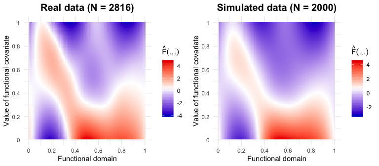

```r
sim_surf <- vis_surf(coef = apply(sim_coef, c(2, 3), mean), simulation = TRUE,
                          range_x = 1, range_s = 1,
                          trans_name = paste0("Simulated data (N = ", N_pred, ")"))
grid.arrange(real_surf, sim_surf, nrow = 1)
```

To quantify the simulation performance, we calculate the integrated square error (ISE) for each number of simulated subjects. The ISE is defined as
$$\text{ISE}(\hat{F}(s, x)) = \int_\mathcal{S} \int_\mathcal{X} (\hat{F}(s, x) - F(s, x))^2 dxds\;.$$
Here we give an example on drawing the boxplot of ISE based on the 10 simulations. The ISE calculation for estimated cumulative baseline hazards is performed analogously.

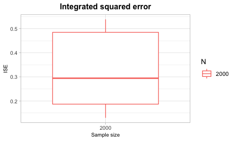

```r
## calculate integrated square error (ISE)
### function "cal_ISE()" calculate the ISE of simulations and return a format ready for visualization
#### nsim: number of simulations
#### sim_coef: the estimated functional surface from simulated data of nsim simulations
#### real_coef: the estimated functional surface from real data
cal_ISE <- function(nsim, sim_coef, real_coef, N_pred){
    ISE <- rep(0, nsim)
    for(i in 1:nsim){
        ISE[i] <- sum((sim_coef[i,,] - real_coef)^2) / (ncol(real_coef) * nrow(real_coef))
    }
    ISE.df <- data.frame(N = rep(as.character(N_pred), nsim), ISE = ISE)

    return(ISE.df)
}
ISE.df <- cal_ISE(nsim = nsim, sim_coef = sim_coef, real_coef = real_coef, N_pred = 2000)

ggplot(ISE.df, aes(x = N, y = ISE)) +
  geom_boxplot(aes(color = N)) +
  xlab("Sample size") +
  ylab("ISE") +
  ggtitle("Integrated squared error") +
  theme_light() +
  theme(axis.text = element_text(size = 8),
        axis.title = element_text(size = 8),
        plot.title = element_text(size = 12, face = "bold", hjust = 0.5))
```

### Simulation with pre-specified forms of $F(\cdot, \cdot)$

In the second simulation component, four different forms of $F(\cdot, \cdot)$ are used to simulate survival data with formulas given above. We provide a sample code to run `nsim = 5` simulations with `N_pred = 5000` subjects per simulation when `model_type = "nonlinear1"`, that is, when true function $F(s, x) = x^3s$. Other cases can be implemented analogously. The estimated surface based on our model (AFCM) and linear functional Cox model (LFCM) are stored in `sim_coef_afc` and `sim_coef_lfc` respectively.

### Sample code to reproduce Figure 7

```r
## introduce variables in the simulation
model_type = "nonlinear1" ## type of F(.,.) to pre-specify, have "const", "linear", "nonlinear1" and "nonlinear2" options corresponding the manuscript
range_x <- 2 ## range of functional value domain
range_s <- 2 ## range of functional domain
nsim <- 5 ## number of iterations
N_pred <- 5000 ## number of subjects to simulate per simulation
sim_coef_afc <- array(NA, dim=c(nsim, 100, 100)) ## store coef matrix for each simulation
sim_coef_lfc <- array(NA, dim=c(nsim, 100, 100)) ## store coef matrix for each simulation
sim_CBH_afc <- matrix(NA, nrow = nsim, ncol = nt_pred) ## store CBH for each simulation
sim_CBH_lfc <- matrix(NA, nrow = nsim, ncol = nt_pred) ## store CBH for each simulation

set.seed(534)
## simulation
for(m in 1:nsim){
    ## simulate functional covariate and survival data
    data_sim <- sim_surv_F(fit = fit_afc_real, N = N_pred, tmax = 10, range_x = range_x, range_s = range_s,
                           time_mort = data_analysis$time_mort, event = data_analysis$event, model = model_type)

    ## fit the AFCM and LFCM model using simulated data, derive estimated surface and cumulative baseline hazards
    grid_coef <- cal_grid_sim(grid_length = 100, x_lo = -1, x_up = 1, s_lo = 0, s_up = 2)

    ### 1. AFCM
    fit_afc_sim <- gam(time_mort ~ ti(t_int, func_cov, by=l_int, bs=c("cr","cr"), k=c(5, 5), mc=c(FALSE,TRUE)), weights = event, data = data_sim, family = cox.ph())
    sim_afc_res <- predict(fit_afc_sim, newdata = grid_coef, type = 'terms')
    sim_coef_afc[m,,] <- matrix(sim_afc_res[,"ti(t_int,func_cov):l_int"], ncol = sqrt(nrow(grid_coef)), nrow = sqrt(nrow(grid_coef)), byrow = FALSE) # re-organize to matrix form

    t0 <- rev(fit_afc_sim$family$data$tr)
    H0_hat <- rev(fit_afc_sim$family$data$h) ## estimate for the baseline cumulative hazard function
    H0_fit <- scam(H0_hat ~ s(t0, bs = "mpi")-1) ## smooth the cumulative hazard
    sim_CBH_afc[m,] <- pmax(0, predict(H0_fit, newdata = data.frame(t0 = tgrid_sim))) ## truncate cumulative hazard at 0
    sim_CBH_afc[m,1] <- 0

    ### 2. LFCM
    fit_lfc_sim <- gam(time_mort ~ s(t_int, by = l_int * func_cov, bs="cr", k = 10), weights=event, data=data_sim, family=cox.ph())
    sim_lfc_res <- predict(fit_lfc_sim, newdata = grid_coef, type = 'terms')
    sim_coef_lfc[m,,] <- matrix(sim_lfc_res[,"s(t_int):l_int * func_cov"], ncol = sqrt(nrow(grid_coef)), nrow = sqrt(nrow(grid_coef)), byrow = FALSE)

    t0 <- rev(fit_lfc_sim$family$data$tr)
    H0_hat <- rev(fit_lfc_sim$family$data$h) ## estimate for the baseline cumulative hazard function
    H0_fit <- scam(H0_hat ~ s(t0, bs = "mpi")-1) ## smooth the cumulative hazard
    sim_CBH_afc[m,] <- pmax(0, predict(H0_fit, newdata = data.frame(t0 = tgrid_sim))) ## truncate cumulative hazard at 0
    sim_CBH_afc[m,1] <- 0
}
```

The average estimated surface using AFCM and LFCM are then derived respectively, and compared with the true surface shown on the left panel below.

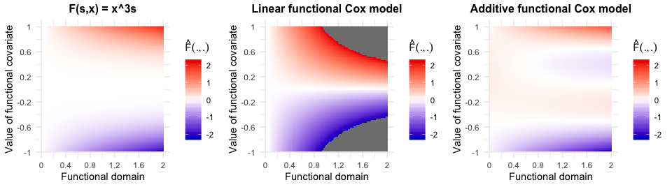

```r
## derive and plot the estimated functional surface from two models
sim_surf_afc_nonlinear1 <- vis_surf_sim(coef = apply(sim_coef_afc, c(2, 3), mean), x_lo = -1, x_up = 1, s_lo = 0, s_up = 2, name = "Additive functional Cox model", lb = -2.2, ub = 2.2)
sim_surf_lfc_nonlinear1 <- vis_surf_sim(coef = apply(sim_coef_lfc, c(2, 3), mean), x_lo = -1, x_up = 1, s_lo = 0, s_up = 2, name = "Linear functional Cox model", lb = -2.2, ub = 2.2)

## derive true surface based on the formula of F(x, s)
xind <- as.matrix(seq(-1, 1, len = 100), ncol = 1)
tind <- as.matrix(seq(0, 2, len = 100), ncol = 1)
real_coef_nonlinear1 <- t(xind^3 %*% t(tind))
real_surf_nonlinear1 <- vis_surf_sim(coef = real_coef_nonlinear1, x_lo = -1, x_up = 1, s_lo = 0, s_up = 2, name = "F(s,x) = x^3s", lb = -2.2, ub = 2.2, fontsize = 12)

grid.arrange(real_surf_nonlinear1 , sim_surf_lfc_nonlinear1, sim_surf_afc_nonlinear1, nrow = 1)
```

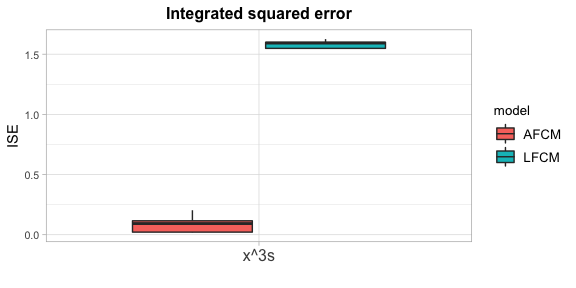

```r
### a similar function with "cal_ISE", introduce "F_form" for flexible notation
cal_ISE_F <- function(nsim, sim_coef, real_coef, F_form, model_name){
    ISE <- rep(0, nsim)
    for(i in 1:nsim){
        ISE[i] <- sum((sim_coef[i,,] - real_coef)^2) / (ncol(real_coef) * nrow(real_coef))
    }
    ISE.df <- data.frame(F_form = rep(as.character(F_form), nsim), ISE = ISE, model = rep(as.character(model_name), nsim))

    return(ISE.df)
}

ISE.df_afc_nonlinear1 <- cal_ISE_F(nsim = nsim, sim_coef = sim_coef_afc, real_coef = real_coef_nonlinear1, F_form = "x^3s", model_name = "AFCM")
ISE.df_lfc_nonlinear1 <- cal_ISE_F(nsim = nsim, sim_coef = sim_coef_lfc, real_coef = real_coef_nonlinear1, F_form = "x^3s", model_name = "LFCM")
ISE.df_nonlinear1 <- rbind(ISE.df_afc_nonlinear1, ISE.df_lfc_nonlinear1)

ggplot(ISE.df_nonlinear1, aes(x = F_form, y = ISE, fill = factor(model))) +
  geom_boxplot() +
  xlab("") +
  ylab("ISE") +
  ggtitle("Integrated squared error") +
  scale_fill_discrete(name = "model") +
  theme_light() +
  theme(legend.position = "right",
        axis.text.x = element_text(size = 12),
        axis.text.y = element_text(size = 8),
        legend.text = element_text(size = 10),
        legend.title = element_text(size = 10),
        plot.title = element_text(size = 12, face = "bold", hjust = 0.5))
```

### Comparing the performance of two approaches to ensure identifiability

As discussed in the supplementary materials, we can use two approaches to ensure identifiability. The first approach first derives an unconstrained estimate, then subtracts its corresponding sample means. The second approach, instead, directly imposes the identifiability constraints using `ti()` function when fitting the model. We here provide the code to implement both approaches. The plot shows true surface ($F(s, x) = xs$), average unconstrained estimates, and average constrained estimates using both approaches, labeled as `te + post-hoc` and `ti`, from 5 simulations. Both approaches work well in this simulation setting. The unconstrained estimates indicate the importance of additional constraints discussed in Section 2.3 of the paper.

```r
model_type = "linear"
range_x <- 2 ## range of functional value domain
range_s <- 2 ## range of functional domain
nsim <- 5 ## number of iterations
N_pred <- 5000 ## number of subjects to simulate per simulation
sim_coef_afc_raw <- array(NA, dim=c(nsim, 100, 100)) ## array to store coef matrix for each simulation
sim_coef_afc_teph <- array(NA, dim=c(nsim, 100, 100))
sim_coef_afc_ti <- array(NA, dim=c(nsim, 100, 100))

set.seed(129)
ptm <- proc.time()
## simulation
for(m in 1:nsim){
    ## simulate functional covariate and survival data
    data_sim <- sim_surv_F(fit = fit_afc_real, N = N_pred, tmax = 10, range_x = range_x, range_s = range_s,
                           time_mort = data_analysis$time_mort, event = data_analysis$event, model = model_type)
    ## build the grid to estimate
    grid_coef <- cal_grid_sim(grid_length = 100, x_lo = -1, x_up = 1, s_lo = 0, s_up = 2)

    ## 1.fit an unconstrained model
    fit_afc_sim <- gam(time_mort ~ te(t_int, func_cov, by = l_int, bs = c("cr","cr"),k=c(5, 5)), weights = event, data = data_sim, family = cox.ph())
    coef_afc <- predict(fit_afc_sim, newdata = grid_coef, type = 'terms')
    ### unconstrained estimate
    sim_coef_afc_raw[m,,] <- matrix(coef_afc[,"te(t_int,func_cov):l_int"], ncol = sqrt(nrow(grid_coef)), nrow = sqrt(nrow(grid_coef)), byrow = FALSE) # re-organize to matrix form
    ### ensure identifiability by post-hoc correction
    sim_coef_afc_teph[m,,] <- sim_coef_afc_raw[m,,] - rowMeans(sim_coef_afc_raw[m,,]) ## impose post-hoc identifiability constraint

    ## 2.fit a constrained model
    fit_afc_cst <- gam(time_mort ~ ti(t_int, func_cov, by=l_int, bs=c("cr","cr"), k=c(5, 5), mc=c(FALSE, TRUE)), weights = event, data = data_sim, family = cox.ph())
    coef_afc_cst <- predict(fit_afc_cst, newdata = grid_coef, type = 'terms')
    sim_coef_afc_ti[m,,] <- matrix(coef_afc_cst[,"ti(t_int,func_cov):l_int"], ncol = sqrt(nrow(grid_coef)), nrow = sqrt(nrow(grid_coef)), byrow = FALSE) # re-organize to matrix form
}
proc.time() - ptm
```

```
##    user  system elapsed
## 530.729 178.334 882.224
```

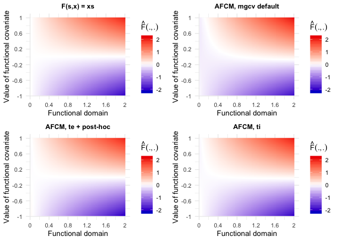

```r
## derive and plot the estimates
sim_surf_afc_raw <- vis_surf_sim(coef = apply(sim_coef_afc_raw, c(2, 3), mean), x_lo = -1, x_up = 1, s_lo = 0, s_up = 2, name = "AFCM, mgcv default", lb = -2.2, ub = 2.2, fontsize = 10)
sim_surf_afc_teph <- vis_surf_sim(coef = apply(sim_coef_afc_teph, c(2, 3), mean), x_lo = -1, x_up = 1, s_lo = 0, s_up = 2, name = "AFCM, te + post-hoc", lb = -2.2, ub = 2.2, fontsize = 10)
sim_surf_afc_ti <- vis_surf_sim(coef = apply(sim_coef_afc_ti, c(2, 3), mean), x_lo = -1, x_up = 1, s_lo = 0, s_up = 2, name = "AFCM, ti", lb = -2.2, ub = 2.2, fontsize = 10)

## true surface
xind <- as.matrix(seq(-1, 1, len = 100), ncol = 1)
tind <- as.matrix(seq(0, 2, len = 100), ncol = 1)
real_coef_linear <- t((xind %*% t(tind)))
real_surf_linear <- vis_surf_sim(coef = real_coef_linear, x_lo = -1, x_up = 1, s_lo = 0, s_up = 2, name = "F(s,x) = xs", lb = -2.2, ub = 2.2, fontsize = 10)

grid.arrange(real_surf_linear, sim_surf_afc_raw, sim_surf_afc_teph, sim_surf_afc_ti, nrow = 2)
```